# Working with sf objects

# Goals:

1. In the first exercise, you will learn to construct maps with tmaps() by modifying the provided code. The libraries, data, and initial code is provided below.
2. In the second exercise, you learn to:
- Understand the provided datasets
- Learn how to reproject spatial data
- Limit your data into an area of interest
- Create a new map
3. In the third exercise, you reproject layers to a shared SRS.
4. In the fourth (and optional) exercise, you create a map of Denmark using online data.

#### Required R libraries

We will use the sf, raster, and tmap packages. Additionally, we will use the spData and spDataLarge packages that provide new datasets. To install the spDataLarge please load it directly from the author’s github repository at https://github.com/Nowosad/spDataLarge. If the line in the chunk below does not work, check the repository for the other options.

```r
pacman::p_load(sf, raster, tmap, spData, spDataLarge)
```

# Exercise 1 - Make a map

In this exercise you will learn to make a map with tmaps library, by adding spatial data layers and modifying the arguments that specify their rendering

#### Data sets

We will use two data sets: `nz_elev` and `nz`. They are contained by the libraries The first one is an elevation raster object for the New Zealand area, and the second one is an sf object with polygons representing the 16 regions of New Zealand.

```r
data("nz")
data(nz_elev)
```

#### Existing code

Here is the code to create a new map of New Zealand (following Robin Lovelace’s example).Your role is to improve this map based on the suggestions below.

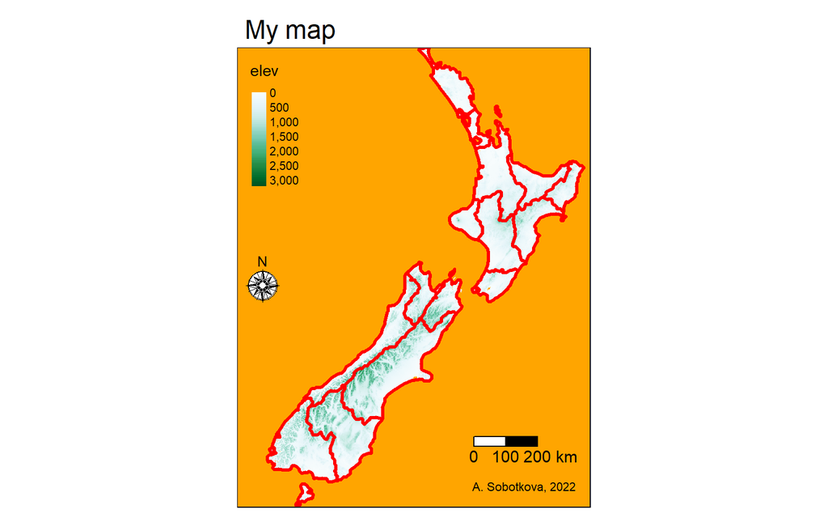

```r
tm_shape(nz_elev)  +
  tm_raster(title = "elev",
            style = "cont",
            palette = "BuGn") +
  tm_shape(nz) +
  tm_borders(col = "red",
             lwd = 3) +
  tm_scale_bar(breaks = c(0, 100, 200),
               text.size = 1) +
  tm_compass(position = c("LEFT", "center"),
             type = "rose",
             size = 2) +
  tm_credits(text = "A. Sobotkova, 2022") +
  tm_layout(main.title = "My map",
            bg.color = "orange",
            inner.margins = c(0, 0, 0, 0))
```

## Tasks

1. Change the map title from “My map” to “New Zealand”.
2. Update the map credits with your own name and today’s date.
3. Change the color palette to “-RdYlGn”. (You can also try other palettes from http://colorbrewer2.org/)
4. Put the north arrow in the top right corner of the map.
5. Improve the legend title by adding the used units (m asl).
6. Increase the number of breaks in the scale bar.
7. Change the borders’ color of the New Zealand’s regions to black. Decrease the line width.
8. Change the background color to any color of your choice.

## Your solution

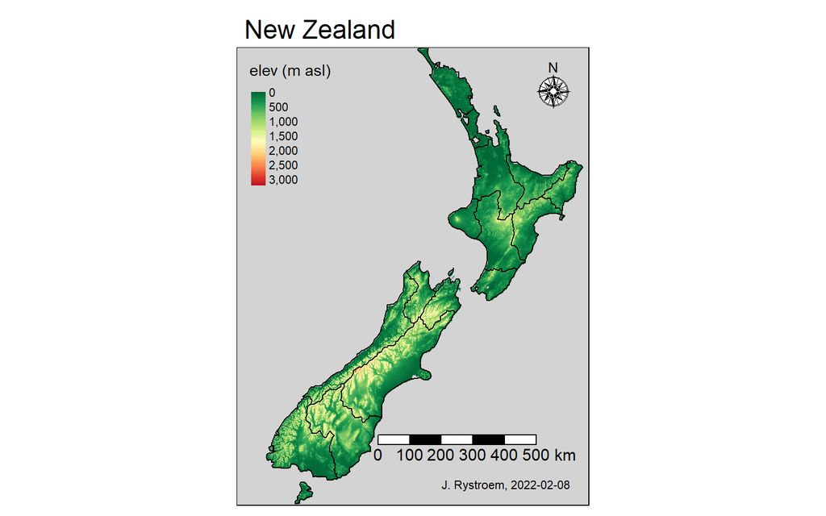

```r
# /Start Code/
tm_shape(nz_elev)  +
  tm_raster(title = "elev (m asl)",
            style = "cont",
            palette = "-RdYlGn") +
  tm_shape(nz) +
  tm_borders(col = "black",
             lwd = 1) +
  tm_scale_bar(breaks = c(0,100, 200, 300, 400, 500),
               text.size = 1) +
  tm_compass(position = c("right", "top"),
             type = "rose",
             size = 2) +
  tm_credits(text = "J. Rystroem, 2022-02-08") +
  # Change title
  tm_layout(main.title = "New Zealand",
            bg.color = "lightgrey",
            inner.margins = c(0, 0, 0, 0))
```

```r
# /End Code/
```

# Exercise 2 - Inspect and display spatial data

Read two new datasets, `srtm` and `zion`, using the code below and then follow the instructions and answer the questions related.

#### Preparation: Load data from provided package

You need to have installed the spDataLarge package for the following code to work.

```r
srtm  <-  raster(system.file("raster/srtm.tif", package = "spDataLarge"))
zion  <-  read_sf(system.file("vector/zion.gpkg", package = "spDataLarge"))
```

## Instructions and questions

Type answers to the questions as code comments next to or under the code used

- Display the `zion` object and view its structure.
  - What can you say about the content of this file?
  - What type of data does it store?
  - What is the coordinate system used?
  - How many attributes does it contain?
  - What is its geometry?
- Display the `srtm` object and view its structure.
  - What can you say about the content of this file?
  - What type of data does it store?
  - What is the coordinate system used?
  - How many attributes does it contain?
  - How many dimensions does it have?
  - What is the data resolution?

## Your solution and answers

```r
# /Start Code / #
######################
# STARTING WITH ZION #
######################

# What can you say about the content of this file? #
zion   # It is a single polygon with 11 fields (vector)
```

```
Simple feature collection with 1 feature and 11 fields
Geometry type: POLYGON
Dimension:     XY
Bounding box:  xmin: 302903.1 ymin: 4112244 xmax: 334735.5 ymax: 4153087
Projected CRS: UTM Zone 12, Northern Hemisphere
# A tibble: 1 x 12
  UNIT_CODE GIS_Notes       UNIT_NAME  DATE_EDIT  STATE REGION GNIS_ID UNIT_TYPE
  <chr>     <chr>           <chr>      <date>     <chr> <chr>  <chr>   <chr>
1 ZION      Lands - http:/~ Zion Nati~ 2017-06-22 UT    IM     1455157 National~
# ... with 4 more variables: CREATED_BY <chr>, METADATA <chr>, PARKNAME <chr>,
#   geom <POLYGON [m]>
```

```r
# What type of data does it store?  #
head(zion)  # A bunch of metadata, ids and relevant urls
```

```
Simple feature collection with 1 feature and 11 fields
Geometry type: POLYGON
Dimension:     XY
Bounding box:  xmin: 302903.1 ymin: 4112244 xmax: 334735.5 ymax: 4153087
Projected CRS: UTM Zone 12, Northern Hemisphere
# A tibble: 1 x 12
  UNIT_CODE GIS_Notes       UNIT_NAME  DATE_EDIT  STATE REGION GNIS_ID UNIT_TYPE
  <chr>     <chr>           <chr>      <date>     <chr> <chr>  <chr>   <chr>
1 ZION      Lands - http:/~ Zion Nati~ 2017-06-22 UT    IM     1455157 National~
# ... with 4 more variables: CREATED_BY <chr>, METADATA <chr>, PARKNAME <chr>,
#   geom <POLYGON [m]>
```

```r
# What is the coordinate system used? #
crs(zion) # It uses the GRS 1980 system
```

[output not shown]

[output cut: 18 more lines]

[output not shown]

```r
# How many attributes does it contain? #
# from inspecting we see it has 11 fields though there is a lot of redundant

# What is its geometry? #
# It is a POLYGON


################
# NEXT UP SRTM #
################

# What can you say about the content of this file? #
srtm   # It is a RasterLayer
```

```
class      : RasterLayer
dimensions : 457, 465, 212505  (nrow, ncol, ncell)
resolution : 0.0008333333, 0.0008333333  (x, y)
extent     : -113.2396, -112.8521, 37.13208, 37.51292  (xmin, xmax, ymin, ymax)
crs        : +proj=longlat +datum=WGS84 +no_defs
source     : srtm.tif
names      : srtm
values     : 1024, 2892  (min, max)
```

```r
# What type of data does it store? #
# class, dimensions, resolution, crs, source, range

# What is the coordinate system used? #
crs(srtm) # It uses the WGS84 system
```

```
Coordinate Reference System:
Deprecated Proj.4 representation: +proj=longlat +datum=WGS84 +no_defs
WKT2 2019 representation:
GEOGCRS["WGS 84 (with axis order normalized for visualization)",
    DATUM["World Geodetic System 1984",
        ELLIPSOID["WGS 84",6378137,298.257223563,
            LENGTHUNIT["metre",1]]],
    PRIMEM["Greenwich",0,
        ANGLEUNIT["degree",0.0174532925199433]],
    CS[ellipsoidal,2],
        AXIS["geodetic longitude (Lon)",east,
            ORDER[1],
            ANGLEUNIT["degree",0.0174532925199433,
                ID["EPSG",9122]]],
        AXIS["geodetic latitude (Lat)",north,
            ORDER[2],
            ANGLEUNIT["degree",0.0174532925199433,
                ID["EPSG",9122]]]]
```

```r
# How many attributes does it contain? #
# Not any apart from the stuff

# How many dimensions does it have? #
# 457 rows and 465 columns

# What is the data resolution? #
# resolution : 0.0008333333, 0.0008333333  (x, y)

# /End Code/ #
```

# Exercise 3 - Reconciling Coordinate systems

Now that you know that coordinate systems differ, make them compatible!

## Instructions

- Reproject the `srtm` dataset into the coordinate reference system used in the `zion` object.
  - Create a new object `srtm2`
  - Visualize the results using the `plot()` function.
- Reproject the `zion` dataset into the coordinate reference system used in the `srtm` object.
  - Create a new object `zion2`
  - Visualize the results (`zion2` together with `srtm2`) using the `plot()` function.

## Your solution

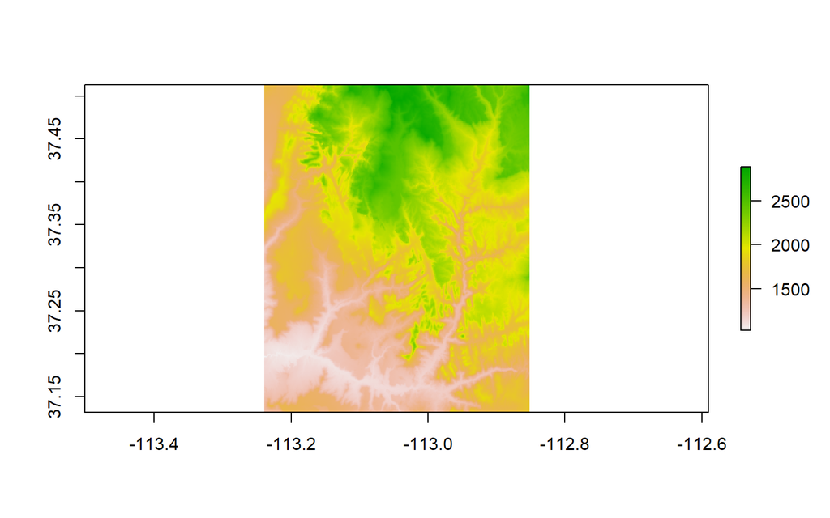

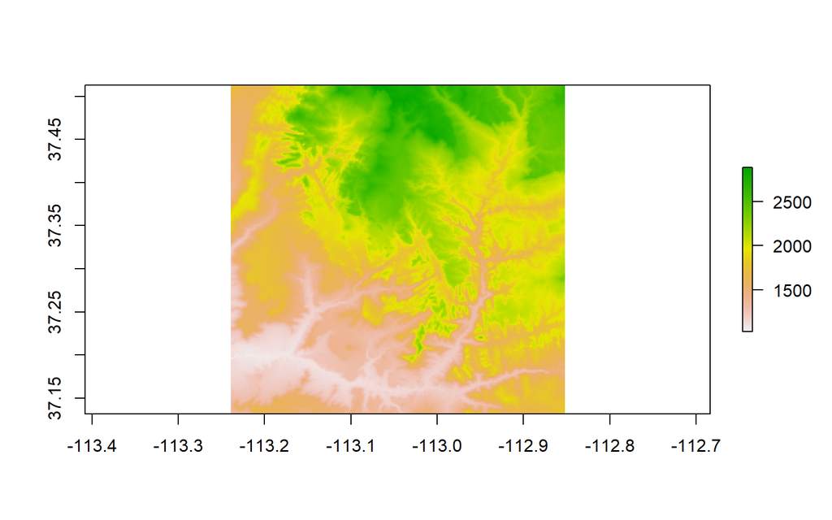

```r
# /Start Code/ #

# Reprojecting srtm with zion #
srtm2 <- srtm
crs(srtm2) <- crs(zion)
plot(srtm); plot(srtm2) # Looking at differences
```

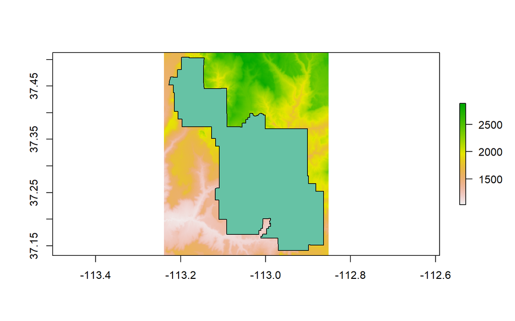

```r
# Reprojecting zion with srtm
zion2 <- st_transform(zion, crs(srtm))
plot(srtm);plot(zion2['UNIT_CODE'], borders="black", add=T)
```

```r
# /End Code/ #
```

Looks weird AF but ¯\*(ツ)*/¯

# Exercise 4 - Make a map of Denmark (Optional)

Make a handsome map of Denmark from data available online with a scale, a north arrow and source credits!

## Hints

*Load elevation and regional boundaries for Denmark using the `getData()` function from the `raster` package.

- Remember that the `getData()` function takes a number of different attributes, plus the country code in a ISO 3-letter format. You can google what it is for Denmark, or use the `getData('ISO3')` function to view it. For an example of how to use the `getData()` function [see this blog](https://www.gis-blog.com/r-raster-data-acquisition/)
- Make a map with `tmaps` library following the Exercise no.1

I’m skipping this week :))